### Example 3

```r
library(shiny)

ui <- fluidPage(

  actionButton("toggle", "Toggle"),

  conditionalPanel(
    condition = "input.toggle%2==0",
    helpText("This is an explanation
      about how this app works...")
  )

)

server <- function(input, output) {}

shinyApp(ui = ui, server = server)
```

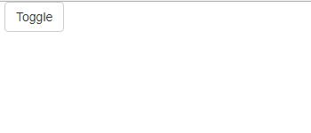

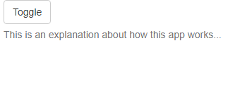

### Example 4

```r
ui <- fluidPage(

  selectInput("format", "Format",
    c("SPSS"=1, "EXCEL"=2, "TXT"=3, "R"=4)),

  conditionalPanel(
    condition = "input.format==3",
    wellPanel(
      radioButtons("sep", "Column sep",
        c(",", ";", "tab"), inline = TRUE),
      radioButtons("dec", "Decimal",
        c(".", ","), inline = TRUE),
      checkboxInput("header", "Header")
    )
  )

)

server <- function(input, output) {}

shinyApp(ui = ui, server = server)
```

Note the **`wellPanel`** to create a frame around the elements, and the **`inline`** argument of **`radioButtons`** function to place the items in horizontal.

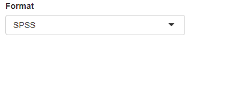

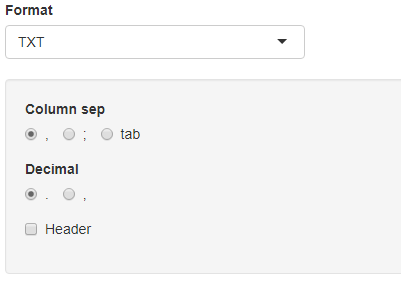

### Example 5

```r
ui <- fluidPage(
  sidebarLayout(
    sidebarPanel(
      conditionalPanel(
        condition = "input.menu=='panel 1'",
        "Now the tab 1 is active"
      ),
      conditionalPanel(
        condition = "input.menu=='panel 2'",
        "Now the tab 2 is active"
      )

    ),
    mainPanel(
      tabsetPanel(id = "menu",
        tabPanel("panel 1",
          "Text in panel 1"
        ),
        tabPanel("panel 2",
          "Text in panel 2"
        )
      )
    )
  )
)

server <- function(input, output) {}

shinyApp(ui = ui, server = server)
```

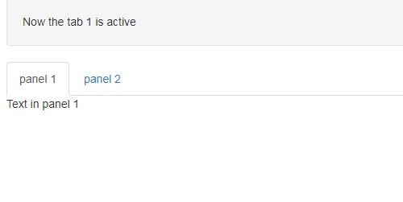

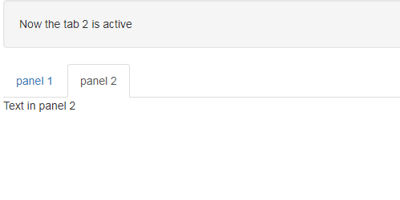

The result is different depending on the active tab.

Exercise

Complete the code in the UI part to place the elements and tabs in the following form:

On the **left hand** of the form it must be a panel where:

- the user can choose one of the following distributions
  - exponential
  - normal
  - binomial
- Depending on the distribution selected, proper parameters must appear so that the user can enter their values:

On the **right hand** of the form there must be two tabs:

- First tab containg a histogram with 1,000 data randomly generated under the selected distribution with the specified parameters.
- Second tab containg a summary of generated data.

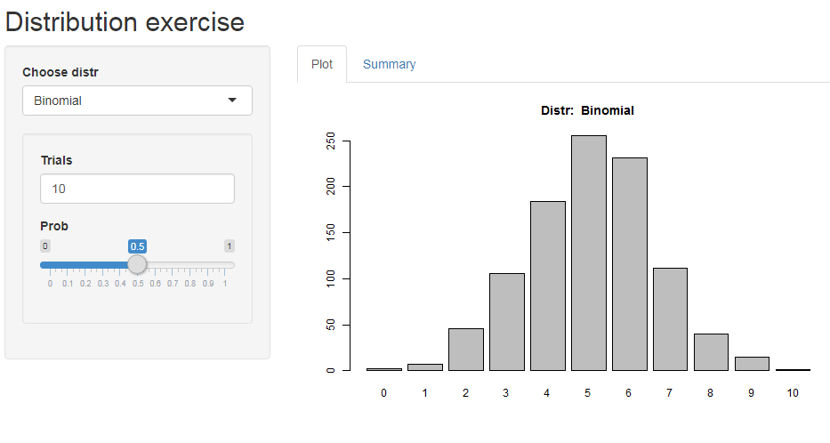

```r
ui <- fluidPage(

   titlePanel("Distribution exercise"),

   sidebarLayout(

      sidebarPanel(

        ## .. to be completed

      ),

      mainPanel(

        ## .. to be completed

      )
   )
)
```

```r
server <- function(input, output) {

  output$summary <- renderPrint({
    if (input$distr=="Normal")
      data <- rnorm(1000, input$mu, input$sd)
    if (input$distr=="Exponential")
      data <- rexp(1000, input$lambda)
    if (input$distr=="Binomial")
      data <- rbinom(1000, input$n, input$p)
    summary(data)
  })

  output$plot <- renderPlot({
    if (input$distr=="Normal")
      data <- rnorm(1000, input$mu, input$sd)
    if (input$distr=="Exponential")
      data <- rexp(1000, input$lambda)
    if (input$distr=="Binomial")
      data <- rbinom(1000, input$n, input$p)
    if (input$distr=="Binomial"){
      datafact <- factor(data, levels=0:input$n)
      barplot(table(datafact))
    } else {
      hist(data, main="")
    }
    title(paste("Distr: ", input$distr))
  })

}
```